# Laiko eilutės: praktinis atsiskaitymas

(papildomi balai)

2024-03-06

# Uždavinių motyvacija

[2020 m. akcijų rinkos kritimas](https://en.wikipedia.org/wiki/2020_stock_market_crash) prasidėjo 2020 m. vasario 20 d. dėl investuotojų nerimo dėl COVID-19 epidemijos pasekmių. Šie investuotojų lūkesčiai aiškiai atsispindi vertybinių popierių biržose prekiaujamų akcijų uždarymo kainose:

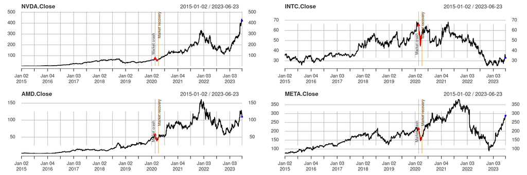

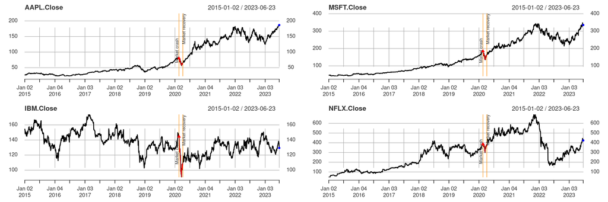

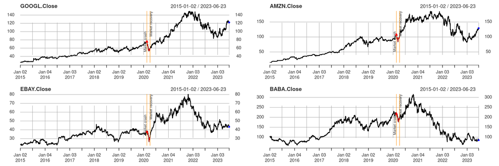

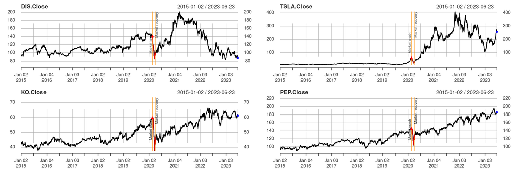

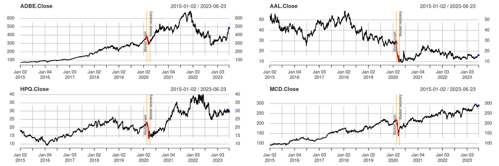

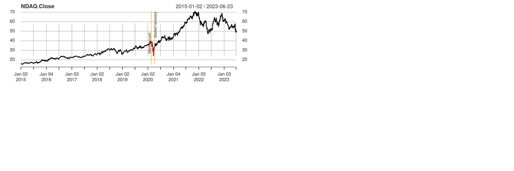

Laikoma, kad akcijų rinkos kritimas tęsėsi iki 2020 m. balandžio 7 d., o po to rinka pradėjo atsigauti. Tačiau galima matyti, kad pastarieji keli metai kai kurioms įmonėms nebuvo sėkmingesni (žiūrint pagal jų akcijų vertę).

Tad iškyla svarbus klausimas: **ar tokie neapibrėžtumo laikotarpiai pasikartos ateityje?**

# Duomenų parsiuntimas ir transformacija iš akcijų kainos į akcijų grąžą

Paleiskite žemiau pateiktą kodą, nurodydami savo studento kodą vietoje `STUDENT_CODE`:

```r
getData <- function(s_code){
  set.seed(s_code)
  symbols_stocks <- c("NVDA", "INTC", "AMD", "META", "AAPL", "MSFT",
                   "IBM", "NFLX", "GOOGL", "AMZN", "EBAY", "BABA",
                   "DIS", "TSLA", "KO", "PEP", "ADBE",
                   "AAL", "HPQ", "MCD", "NDAQ")
  my_symbols <- c(sample(symbols_stocks, 1))
  print(paste0("Simboliai: ", sub("\\^", "", my_symbols)))
  #
  library(quantmod)
  for(var_names in my_symbols){
    # Get the symbol:
    getSymbols(var_names,  auto.assign = TRUE,
               src  = "yahoo",
               from = "2015-01-01",
               to   = "2023-06-25")
    # Automatically remove missing data from the variable:
    assign(gsub("\\^", "", var_names), na.omit(get(gsub("\\^", "", var_names))))
  }
  return(get(var_names))
}
DT <- getData(STUDENT_CODE) # Pakeisti savo studento kodu
saveRDS(DT, "./laiko_eiluciu_duom.RDS")
```

**SVARBU: geriausiai būtų šį kodą įdėti į ataskaitą, kad būtų aiškiai matoma, koks simbolis buvo priskirtas pagal nurodytą studento kodą.**

Pagal nurodytą studento kodą - gausite vieną iš šių finansinių simbolių:

**Įmonių akcijų simbolių reikšmės:**

| SIMBOLIS | ĮMONĖ |
| --- | --- |
| NVDA | NVIDIA Corporation |
| INTC | Intel Corporation |
| AMD | Advanced Micro Devices, Inc. |
| META | Meta (former Facebook) Platforms Inc |
| AAPL | Apple Inc. |
| MSFT | Microsoft Corporation |
| IBM | IBM Common Stock |
| NFLX | Netflix Inc. |
| GOOGL | Alphabet Inc Class A |
| AMZN | Amazon.com, Inc. |
| EBAY | eBay Inc. |
| BABA | Alibaba Group Holding Ltd - ADR |
| DIS | Walt Disney Co. |
| TSLA | Tesla Inc. |
| KO | Coca-Cola Co. |
| PEP | PepsiCo, Inc. |
| ADBE | Adobe Inc. |
| AAL | American Airlines Group Inc. |
| HPQ | HP Inc. |
| MCD | Mcdonald’s Corp. |
| NDAQ | Nasdaq Inc. |

Laikykite, kad:

- laikas yra nuoseklus (t.y. ignoruokite nedarbo dienas ir laikotarpius su tuščiomis (`NA`) reikšmėmis),
- ignoruokite valiutų kurso efektus,
- $P^{(F)}_t$ - nagrinėjamos įmonės akcijų **uždarymo** kaina (*angl.* closing price) laiko momentu $t$.

Pasinaudoję įmonės akcijų ir akcijų indekso simbolių [uždarymo kainomis](http://zodynas.vz.lt/Uzdarymo-kaina) apskaičiuokite paprastąsias grąžas. Išreikškite paprastąsias grąžas logaritmuota išraiška ir toliau analizuokite logaritmuotas grąžas.

# Orientaciniai klausimai

**SVARBU: jeigu bandant sudaryti modelį koeficientai nėra statistiškai reikšmingi - sumažinkite analizuojamų duomenų laikotarpį, pvz. pradžia nuo 2020 sausio mėn.**

Rekomendacijos analizuojant duomenis ir sudarant modelius:

- Naudoti `rugarch` paketą (žr. [aprašymą](https://cran.r-project.org/web/packages/rugarch/vignettes/Introduction_to_the_rugarch_package.pdf)),
- Logaritmuotų grąžų vidurkio, standartinio nuokrypio, asimetrijos (*angl.* skewness) ir eksceso (*angl.* excess kurtosis) koeficientų apskaičiavimas.
- Statistinių testų atlikimas patikrinti ar:
  - vidurkis statistiškai reikšmingai nesiskiria nuo nulio,
  - asimetrijos koeficientas statistiškai reikšmingai nesiskiria nuo nulio,
  - eksceso koeficientas statistiškai reikšmingai nesiskiria nuo nulio.
- Modelio sudarymas (vidurkio lygtis) - pvz. $\rm ARMA$ modelis.
- Modelio liekanų analizė:
  - ar liekanos autokoreliuotos?
  - ar liekanoms būdingi $\rm ARCH$ efektai?
- Padalinkite laiko eilutę į treniravimo ($80\%$) ir testavimo (likę $20\%$) imtis. Modelius sudarykite treniravimo, o prognozuokite testavimo imčiai.
- Modelio sudarymas vidurkio modelio liekanoms(volatilumo/dispersijos lygtis): $\rm ARCH$, $\rm GARCH$ ir jų modifikacijos (pvz., $\rm IGARCH$, $\rm EGARCH$, $\rm GJR-GARCH$, $\rm T-GARCH$).
- Volatilumo lygties standartizuotų liekanų analizė: šio modelio liekanom būdinga autokoreliacija ir $\rm ARCH$ efektai?
- Jungtinio modelio (vidurkiui ir volatilumui) sudarymas, remiantis prieš tais vidurkio ir volatilumo modeliais. Pvz. Jeigu vidurkiui buvo sudarytas $\rm ARMA(P, Q)$, o jo liekanoms $\rm IGARCH(p,q)$, tai jungtinis modelis būtų $\rm ARMA(P,Q)-GARCH(p,q)$
- Jungtinio modelio liekanų analizė,
- Volatilumo prognozės (pagal testavimo imties ilgį) naudojantis sudarytu modeliu - ar prognozuojama didesnė, ar mažesnė rizika? Ar volatilumo prognozė suderinama su tuo, kad faktinė grąža pasižymėjo didesniu (arba mažesniu) neapibrėžtumu testavimo imtyje?